# 2 Modules

### `Results`

[figure not shown]

### `Explore and Plot`

#### Select `dendrogram` plot type to focus on the relationship between HCA ordering and metadata set in the `node` >> `annotations` menue.

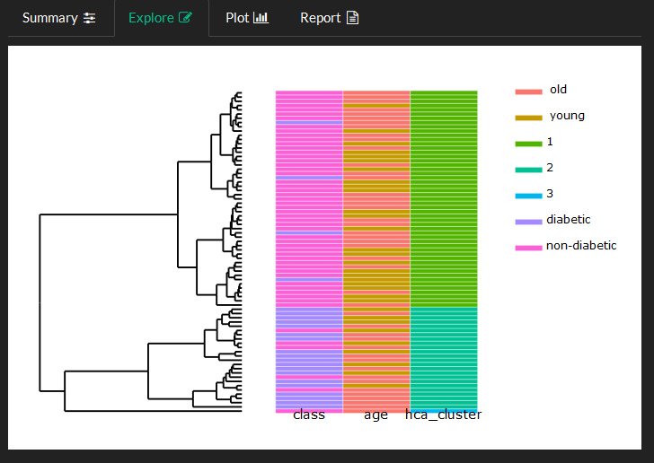

#### Select `explore` and `heatmap` plot type to overveiw sample and/or variable similarities and groups.

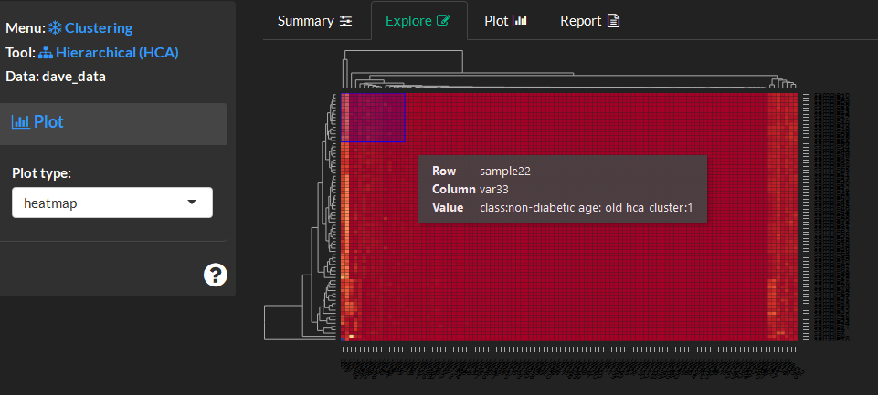

#### Click and drag the mouse on the heat map to zoom in.

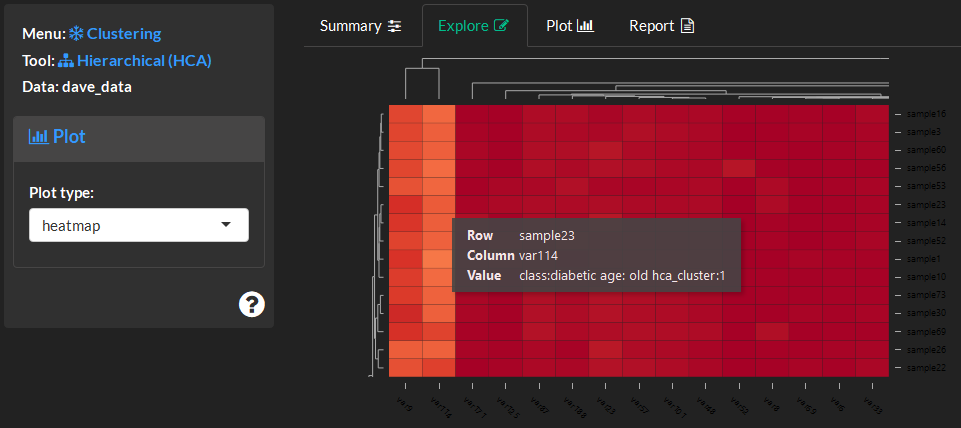

#### Use `plot` >> `heatmap` to visualize heatmap and metadata.

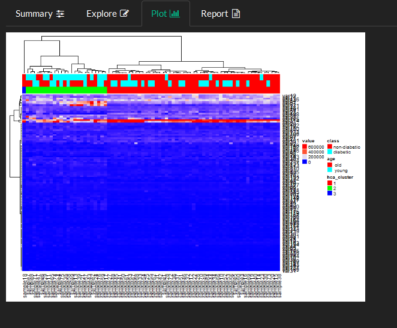

## 2.5 Multivariate Analysis

### 2.5.1 Reference

## **Multivariate**

This module supports dimensional reduction and projection pursuits.

### Principal Components Analysis (PCA)

Principal components analysis (PCA) can be used to summarise the major modes of variance in the data by fewer and uncorrelated principal components (PCs). It is helpful to analyze how sample and variable meta data is related to PCA sample scores and variable loadings.

### `Methods`

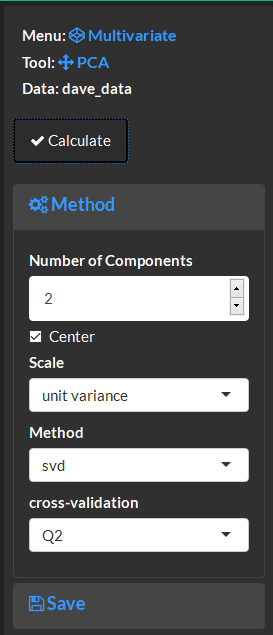

#### Specify the PCA method and normalize the data through centering and scaling.

### `Results`

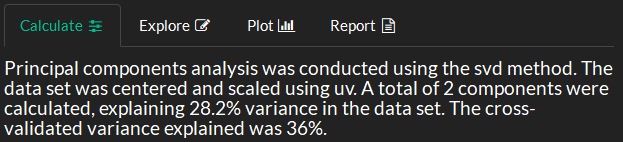

#### Overview methodsand the variance explained by the PCA model.

### `Explore and Plot`

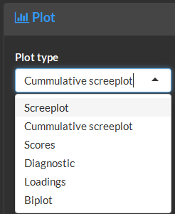

#### Select from a variety of plot types.

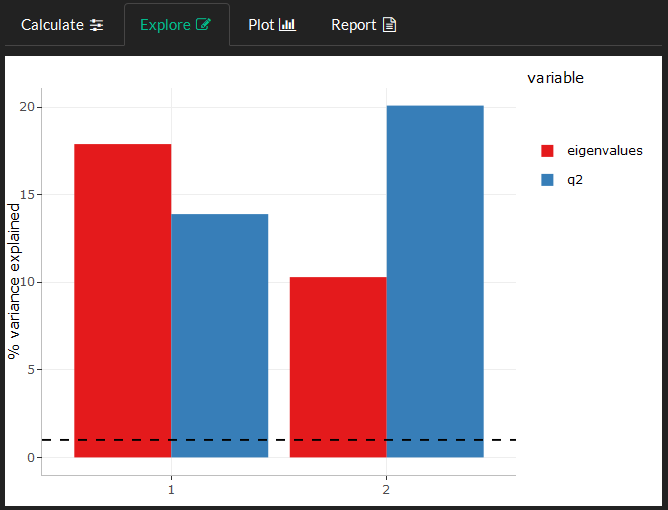

#### The `screeplot` shows the variance explained by each PC. The dashed line marks the 1 % variance limit below which components can be ommited.

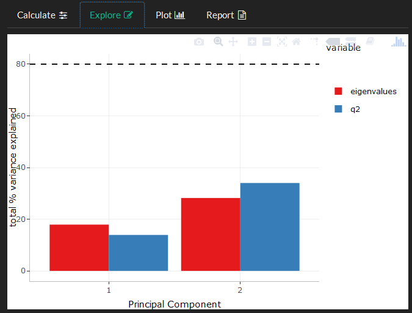

#### Use `cummulative screeplot` to view the total % variance explained. The dashed line shows the boundary where 80% of the original variance in the data has been captured by the PCA model.

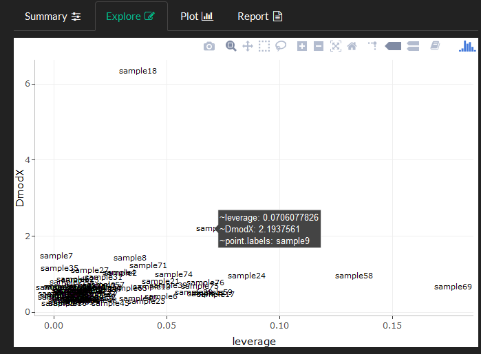

#### The `diagnostics` plot can be used to identify moderate and extreme sample outliers. Large sample `leverage` denotes a large influence of the samples variance to the identification of the PC components (outliers). The `DmodX` or highlights moderate multivariate sample differences. Samples showing both high `leverage` and `DmodX` shoudl be investigated further.

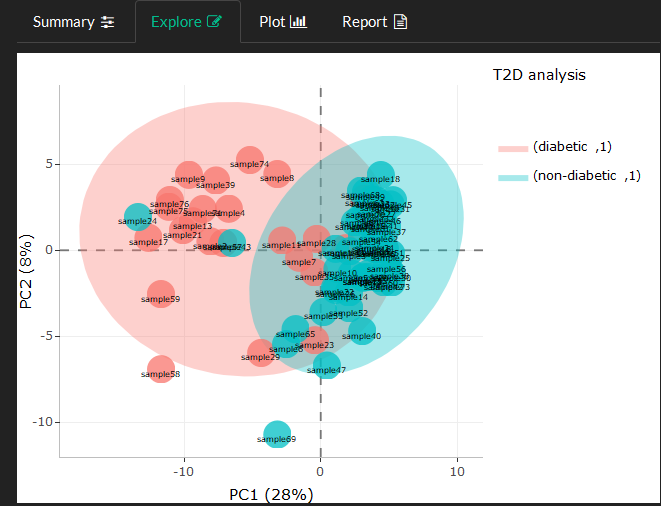

#### Sample `scores` display multivariate similarities through proximity to other samples in the PCA space.

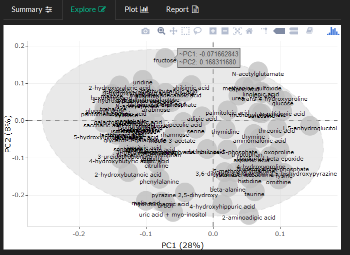

#### The `loadings` plot displays variable similarities.

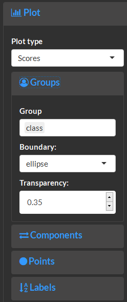

#### The plotting menue for `scores` and `loadings` can be used to select PCs to view, map meta data to plot colors and group boundaries showing the Hoettlings T2 ellipse and modify plot asthetics.

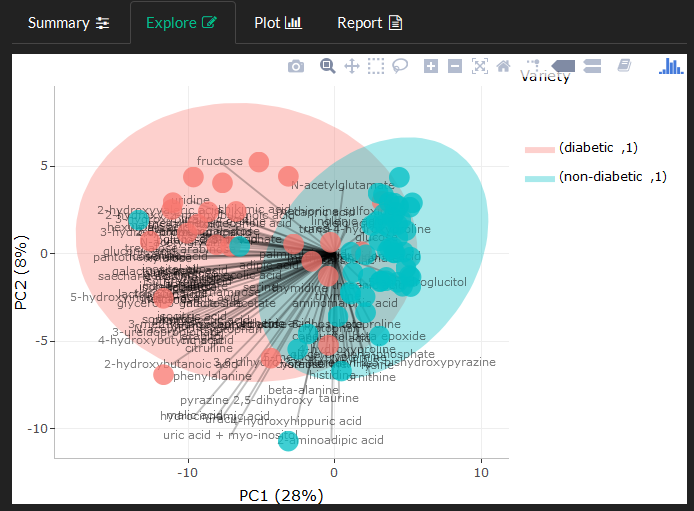

#### The `biplot` can be used to simultaneously visualize sample scores and loadings over layed on top of each other. Variables with extreme loadings (large positive or negative x/y position) have the largest effects on the sample scores (may correspond to low or high values among samples with similairly extreme scores compared to others).

## 2.6 Pathway Analysis

### 2.6.1 Reference

## **Pathways**

This module is used to test for significant enrichment in biological pathways and visualize the results.

### Pathway enrichment and visualization

Pathway`enrichment` is calculated using the hypergeometric test. This module uses the `KEGG` reference organism (ko) database.

### `Methods`

#### Select the name of the column with`KEGG` id for each variable. Filter which variables will be tested for pathway enrichment based on statistical test `p-values` and significance `cut off`.

[figure not shown]

#### Filter `enrichment` results based on the p-value `cutoff` and false dicovery rate (`FDR`) adjustment.

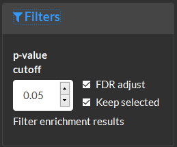

### `Results`

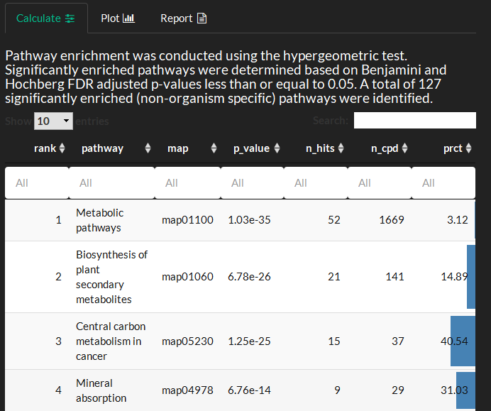

#### Overview the enrichment test methods and tabular results where: `map` is the KEGG pathway map id, `n_hits` is the number of significant variables from this pathway, `n_cpd` the number of compounds in the pathway and `prct` is the percent of enriched variables compared to total pathway variables. Selection of interesting pathways to investigate further could involve: 1) verifying that the pathway has a moderate minimum number of variables (e.g. > 10) 2) identifying low `p-value` and high `prct` enriched pathways 3) visualizing the network topology of enriched variables in the pathway (e.g. look for metabolic proximity of cha ges which may signify a functional module) . NOTE: Some very large and generic pathways such as `Metabolic pathways` can take a few minutes to render.

### `Explore and Plot`

#### Select pathway name and identify the column to use as the `fold-change` to view variable changes mapped to the pathway.

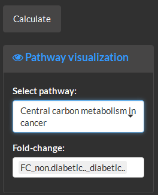

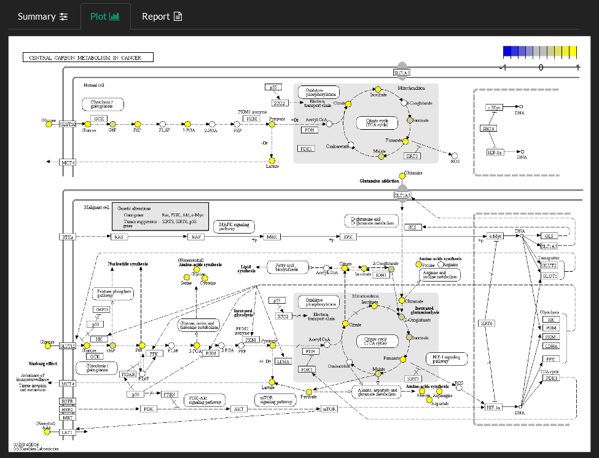

#### The `fold-changes` normalized to between -1 and 1 are mapped onto pathway entities as described in the color bar in the top right corner.

### `Report`

#### Select the number of top pathways (based on `p-value`) to show in table outputs and which `pathways` to show visualizations of.

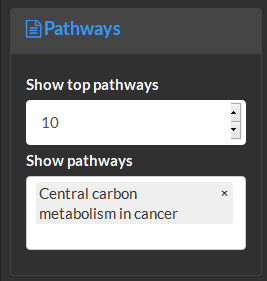

## 2.7 Predictive Modeling

### 2.7.1 Reference

## **Predictive modeling**

Create and optimize machine learning models for classification and regression tasks.

### Train

`Train` is used to fit, optimize and validate models.

### `Methods`

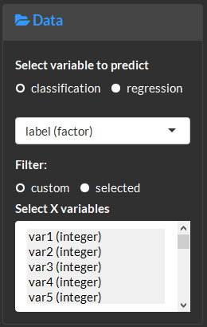

#### Selecting the type of model you would like to create `classification` or `regression` will toggle the available variables to predict. Use the filter menu `selected` to specify which variables should be included in the model based on criteria generated in other modules (e.g. statistical and feature selection).

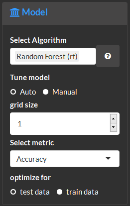

#### The `model` menu is used to specify a single or multiple models to fit to the data. The model hyperparameters can be automatically tuned based on `grid size` which defines the number or random setting to test. Specific model hyperparameters can be specified using the `manual` setting. Note when fitting multiple models tuning will be done in the `auto` mode. The `optimize for` is used to specify if you want to select the best model based on performance on the `training` or held out `test` data (recommended).

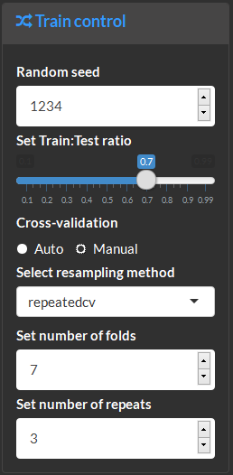

#### This menu is used to specify the `training` and `test` data and model cross-validation parameters. Similar to the `model>>tune` the cross-validation parameters can be `manually` or `automatically` set. For example, the selections shown in the example will randomly select 70% of the data (samples) to fit the model which will then be validated on the 305 held out or `test` data. The model will be internally cross-validated by splitting the `training` data into `7` folds and then leaving out each fold during the model fit and then testing the performance on the held-out fold. This process will be repeated `3` times and the performance on the `training` data will be summarized over all the results.

### `Results`

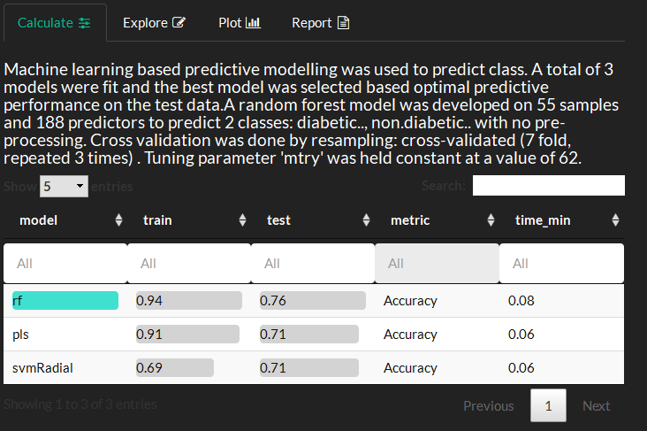

### `Explore and Plot`

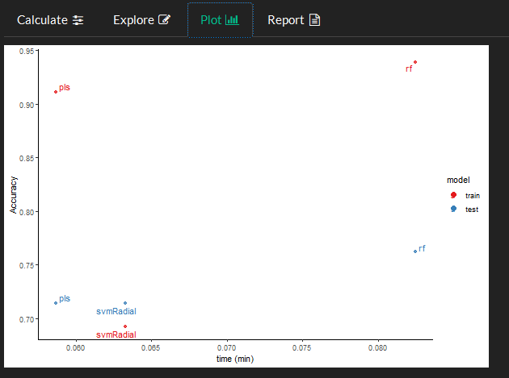

#### Model performance for the `training` and `test` data and training time can be compared.

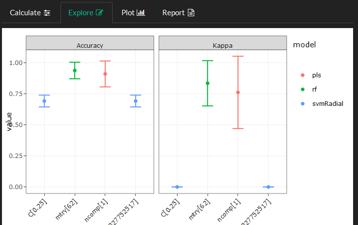

#### This plot is used to visualize the impact of hyperparameters on model performance.

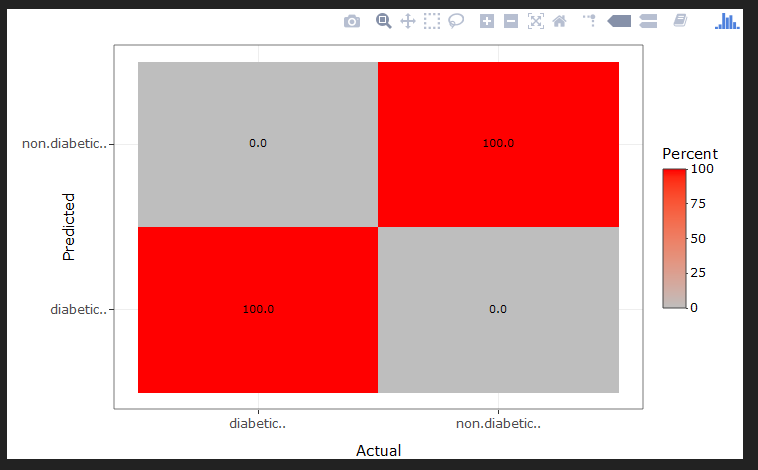

#### Identify the proportion of miss classified samples.

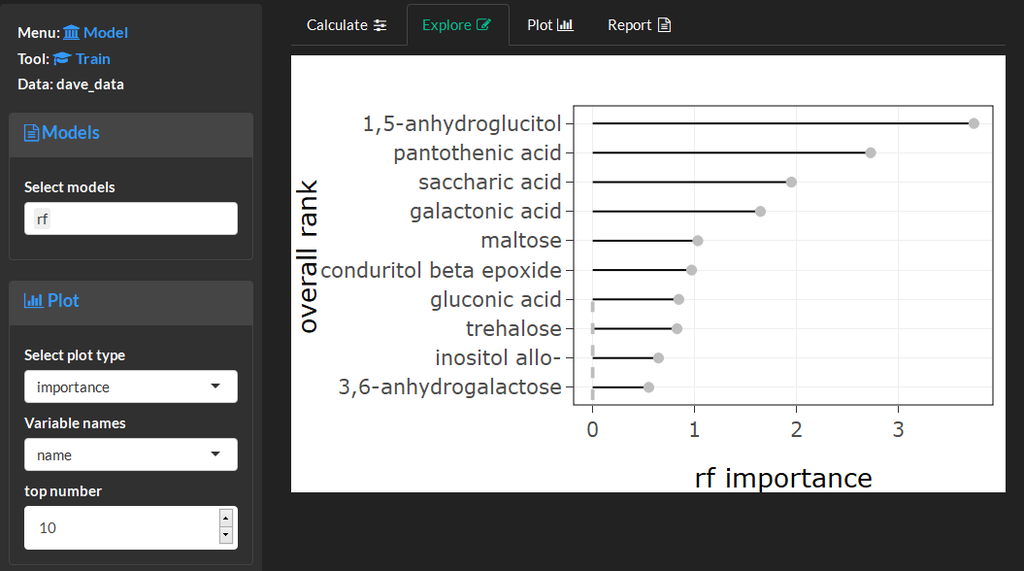

#### Visualize variable's importance or contribution to the model's performance. Importance for multiple models is calculated based weighted metric of the model’s performance and each variables importance in the model. Importance based on multiple models displays the variables consensus rank (y-axis) across all models and the actual importance in the single highest performing model (x-axis).

### Feature selection

`Feature selection` is used to identify variables which maximize model performance. Optimal variables are identified using recursive feature elimination wherein many models are built from subsets of variables and an optimal model is identified based on which subset yielded the highest performing model.

### `Methods`

#### The `data` menu is used to specify the model type and select target and predictor variables.

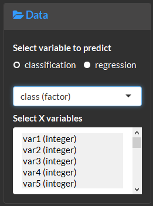

#### The `optimize` menu is used to specify the algorithm used for the selection. The metric specifies which performance criteria will be used to identify the optimal subset of variables.

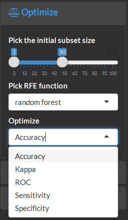

#### The `validate` menu is used to specify the model cross-validation parameters and size of the automatic hyperparameter tuning grid.

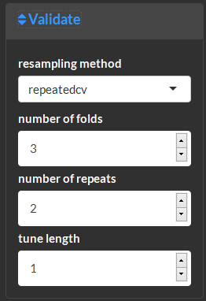

### `Results`

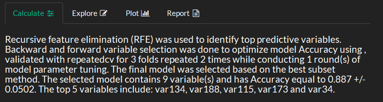

### `Explore and Plot`

#### This visualization displays model performance (y-axis) based on the subset of variables (x-axis). The optimal model is highlighted in red. The plot controls can be used to specify which model metric will be used for the visualization (use `calculate` to optimized subsets for that metric). The optimal variables can be selected based on the `subset function`. Options include `PickSizeBest` which specifies the subset which maximized or minimized the chosen performance metric or `PickSizeTolerance` which allows for models with less parameters (variables), which are also worse than the optimal model. The accepted decrease in performance is specified as a percent of the metric in `tolerance`.

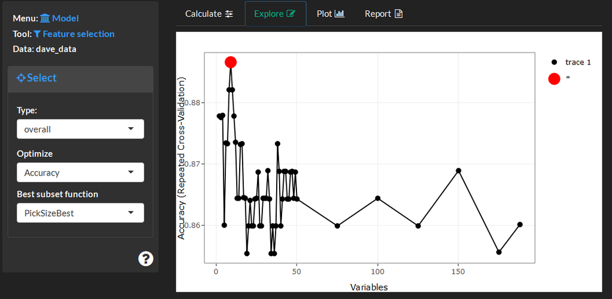

#### This visualizations shows the selected variables (red) importance compared to those which were removed (blue).

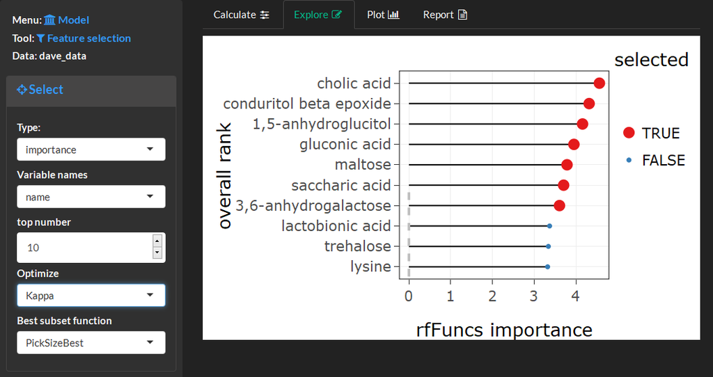

### `Save`

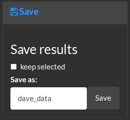

## 2.8 Network Analysis

### 2.8.1 Summary

The network module provides tools to calculate a variety of networks including:

- Correlation and regularized partial correlation
- Biochemical relationships
- Structural similarity

The separately calculated networks can be merged and visualized or exported for visualization in other tools.

- Enrich combine, customize and visualize networks

Biochemical networks

To calculate biochemical networks, choose the Biochemical item from the network navbar. Then select the column name which contains KEGG identifiers for variables.

[figure not shown]

Select the calculate button and overview the results.

[figure not shown]

Save the calculated network for export or to combine with other results.

[figure not shown]

Structural similarity

To calculate metabolite relationships based on structural similarity choose the Structural item from the network navbar. Then select the column name containing PubChem CIDs (chemical identifiers).

[figure not shown]

Important:, supplying non-valid CIDs or related SIDs (Structure Identifiers) may cause method failures or incorrect results. You can validate the CIDs through the [pubchem website](https://pubchem.ncbi.nlm.nih.gov/) or use the translation module.

Once the identifier is selected click the calculate button and overview the results. Note first time calculations for metabolites not present in your DAVe environment may take a moment to download and process but will be cached to your local database and be quickly retrieved next time.

[figure not shown]

A common approach is to remove variables with score ≤ 0.7. However, this may omit metabolites with weak relationships from the network. Currently, inclusion of multi-filter criteria needs to be done outside of DAVe.

Use the visualize menu in the navbar to filter connections based on the tanimoto similarity score.

[figure not shown]

In the visualize tab select the edges menu from the sidebar. The item ‘greater than’ and change the value to 0.7. Plot the results to apply the filter to the network.

[figure not shown]

View the updated results in the calculate tab and save the network. Note, the edges can be saved unfiltered and then formatted outside of DAVe.

[figure not shown]

Save the calculated network for export or to combine with other results.

[figure not shown]

Enrich

Use the enrich menu to combine, format and visualizenetworks.

Combine multiple networks into one. Select networks calculated from the same data source or sharing a network index.

[figure not shown]

After the networks are selected click the calculate button and overview the results.

[figure not shown]

Save the results to visualize or export.

[figure not shown]

Export network results

Navigate to the Data navbar menu and select the network data fropm the Datasets sidebar menu.

The _edges and _nodes contain the edge list and node attributes, respectively. Select each item one by one and use the save menu in the sidebar to export as .csv files.

[figure not shown]

### 2.8.2 Publication quality networks

Creating networks in [Cystoscape](https://cytoscape.org/)

The following example shows how to use Cytoscape (v3.7.2) to create publication ready networks from assets calculated in DAVe. This example will use two components the edge_list and the node_data files.

edge_list.csv

[figure not shown]

node_data.csv

[figure not shown]

Upload edge_list

In cytoscape select File >> Import >> network from File Upload and then select the edge_list.csv file.

[figure not shown]

Set from and to columns

[figure not shown]

from set to Source Node

[figure not shown]

to set to Target Node

[figure not shown]

Select OK once the source and target columns are identified.

Overview network

[figure not shown]

Upload node _data. Select File >> Import >> Table from File

[figure not shown]

Select the ID column as the variable Key

[figure not shown]

The uploaded node attributes should now be available to edit the network node and edge visual properties.

[figure not shown]

Specify the node and edge visual properties.

[figure not shown]

Take a look at the example cytoscape.cys file for how each of the data columns were mapped to the network.

### 2.8.3 Reference

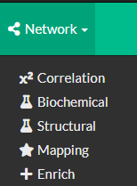

#### Calculate and visualialize complex networks. Use network mapping to integrate your statistical, functional and machine-learning results.Current network options include: correlation and partial correlation, biochemical relationships, structural similarity and network mapping and visualization.

### Empirical networks

This module is used to calculate and `regularized` `correlation` networks.

### `Methods`

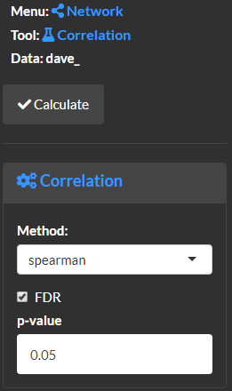

#### Select correlation type and if p-valuse should be False discovery rate corrected.

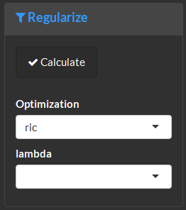

#### Select regularizationm method based on rotation information criterion (ric), stability approach to regularization selection (stars) or extended Bayesian information criterion (ebic).

### `Results`

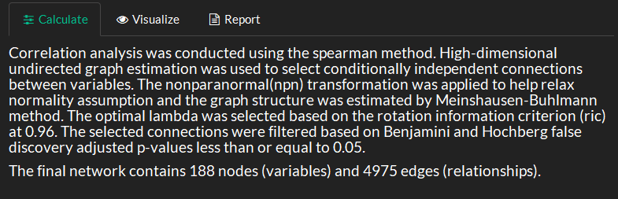

#### Get methods and summary for the calculated network.

### Biochemical networks

This module is used to calculate and `biochemcial` networks. Metabolomic precursor to product relationships are based on `KEGG` identifiers.

### `Methods`

#### Select KEGG (https://www.genome.jp/kegg/) identifier column name in the data.

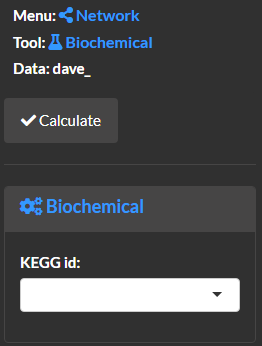

### `Results`

#### Get methods and summary for the calculated network.

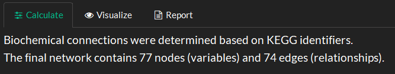

### Structural similarity networks

This module is used to calculate and `structural` simialrity networks. Metabolite `structural` similarities are calculated based on overlap in Pubchem structural fingerprints defined by `compound identifiers` or `CID` (see more: https://pubchem.ncbi.nlm.nih.gov/).

### `Methods`

[figure not shown]

#### Select Pubchem CID (https://pubchem.ncbi.nlm.nih.gov/search/help_search.html) identifier column name in the data.

### `Results`

[figure not shown]

#### Get methods and summary for the calculated network.

### Enrich networks

This module is used to combine and visualize networks.

### `Methods`

#### `Select` networks to combine and visualize.

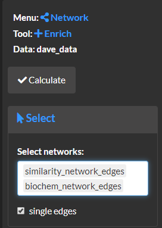

#### `Update` network node attributes based on another compatible data set.

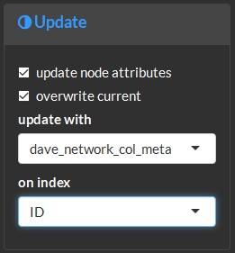

### `Results`

#### View combined network summary.

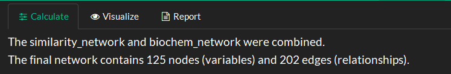

### Visualize networks

Use network mapping to plot and enrich networks.

### `Methods`

#### Visualize variable information through annotation of network node properties such as: name, color, size and shape.

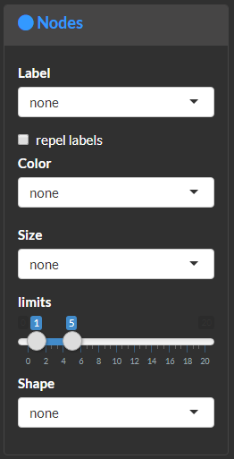

#### Modify and filter edges or relationships.

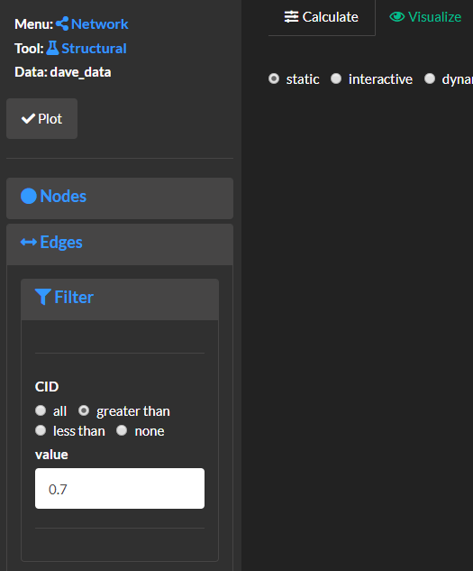

#### Customize network global properties.

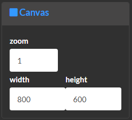

#### Customize network global properties.

[figure not shown]